# torch_sph_mine

```python
%env NUMBA_CUDA_LOW_OCCUPANCY_WARNINGS=0
import torch
import taichi as ti
import numba.cuda as cu
import matplotlib.pyplot as plt
import math
import pandas as pd

ti.init(arch=ti.cuda)
```

```
env: NUMBA_CUDA_LOW_OCCUPANCY_WARNINGS=0
[Taichi] Starting on arch=cuda
```

Reference:

- [SPH Techniques for the Physics Based Simulation of Fluids and Solids](https://interactivecomputergraphics.github.io/SPH-Tutorial/pdf/SPH_Tutorial.pdf)
  - I borrow the kernel function from here.
- [A first course in continuum mechanics](https://doi.org/10.1017/CBO9780511619571)
  - I borrow the Fluid Equations from here.
- [Particle-based fluid simulation for interactive applications](https://dl.acm.org/doi/10.5555/846276.846298)
  - I borrow the Equation of State from here.
- [Nvidia warp's SPH example](https://github.com/NVIDIA/warp/blob/main/examples/example_sph.py)
  - Refer to its implementation

## Equations

Elastic Fluid Equation(compressible, inviscid):

$$ \left\{ \begin{aligned} \frac{dv}{dt} = -\frac{1}{\rho}\nabla p + b \\ \frac{d\rho}{dt} + \rho \nabla \cdot v = 0 \\ \end{aligned} \right. $$

Ignore the second equation(conservation of mass).

Equation of State:

$$ p = k(\rho - \rho_0) $$

```python
def cal_p(kappa, rho, rho_0):
	return kappa * (rho - rho_0)
```

Final Equation to solve:

$$ \left\{ \begin{aligned} \frac{dv}{dt} &= -\frac{1}{\rho}\nabla p + b \\ p &= k(\rho - \rho_0) \\ \end{aligned} \right. $$

## Time Discretization

Use [explicit euler](https://en.wikipedia.org/wiki/Euler_method) to solve the ODE for $v$:

$$ \frac{dv}{dt} \approx = \frac{v|_{t+1} - v|_t}{\Delta t} = a|_t = -\frac{1}{\rho|_t}(\nabla p)|_t + b|_t $$

```python
def v_explicit_euler(v, dt, a):
	return v + dt * a
```

```python
def cal_a(b, grad_p, rho):
	return b - grad_p / rho.view((rho.shape[0], 1))
```

Use [implicit euler](https://en.wikipedia.org/wiki/Backward_Euler_method) to solve the ODE for $x$:

$$ \frac{dx}{dt} \approx = \frac{x|_{t+1} - x|_t}{\Delta t} = v|_{t+1} $$

```python
def x_implicit_euler(x, dt, v):
	return x + dt * v
```

## Spatial Discretization

Use kernel approximation to estimate partial differentials.

Kernel function:

$$ W(\delta) = \sigma_d \left\{ \begin{aligned} & 6(q^3 - q^2) + 1 &, q \in [0, \frac{1}{2}] \\ & 2(1-q)^3 &, q \in [\frac{1}{2}, 1] \\ & 0 &, otherwise \\ \end{aligned} \right. $$

where $$ \begin{aligned} q &= \frac{\delta}{h} \\ \sigma_d &= \left\{ \begin{aligned} & \frac{4}{3h} &,d=1 \\ & \frac{40}{7\pi h^2} &,d=2 \\ & \frac{8}{\pi h^3} &,d=3 \\ \end{aligned} \right. \end{aligned} $$

$h$ is the *support radius of the kernel function*, $d$ is the *dim size*.

```python
@ti.func
def cal_W_2d(delta, h):
	q = delta / h
	sigma = 40.0 / ( 7.0 * 3.1415926 * h * h)

	res = 0.0
	if q >= 0.0 and q <= 0.5:
		res = sigma * (6.0*(q*q*q - q*q) + 1.0)
	elif q <= 1:
		res = sigma * (2.0*(1.0-q)*(1.0-q)*(1.0-q))
	else:
		res = 0.0
	return res
```

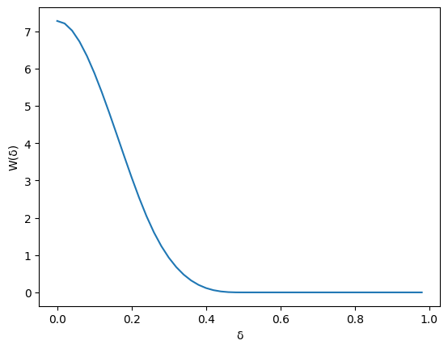

```python
def test_W_2d():
	h = 0.5
	delta = torch.arange(0, 2*h, 2*h/50).cuda()
	W = torch.empty_like(delta)

	@ti.kernel
	def kernel_test(W: ti.types.ndarray(), delta: ti.types.ndarray(), h: float):
		for i in range(delta.shape[0]):
			W[i] = cal_W_2d(delta[i], h)
	kernel_test(W, delta, h)

	plt.plot(delta.cpu().numpy(), W.cpu().numpy())
	plt.xlabel("δ")
	plt.ylabel("W(δ)")
	plt.show()

test_W_2d()
```

Kernel function's derivative:

$$ \frac{\partial W(\delta)}{\partial \delta} = \frac{\sigma_d}{h} \left\{ \begin{aligned} & 6(3q^2 - 2q) &, q \in [0, \frac{1}{2}] \\ & -6(1-q)^2 &, q \in [\frac{1}{2}, 1] \\ & 0 &, otherwise \\ \end{aligned} \right. $$

```python
# @ti.func
# def cal_derivative_W_2d(delta, h):
	# res = 0.0
	# if delta >= 0 and delta <= h:
		# sigma = 30 / (math.pi
			# # 素晴らしい h^5
			# * h * h
			# * h * h * h
		# )
		# res = h - delta
		# res = res * res
		# res = - sigma * res
	# return res
@ti.func
def cal_derivative_W_2d(delta, h):
	q = delta / h
	sigma = 40.0 / ( 7.0 * 3.1415926 * h * h)

	res = 0.0
	if q >= 0.0 and q <= 0.5:
		res = sigma / h * (6.0*(3*q*q - 2*q))
	elif q <= 1:
		res = sigma / h * ( - 6.0*(1.0-q)*(1.0-q))
	else:
		res = 0.0
	return res
```

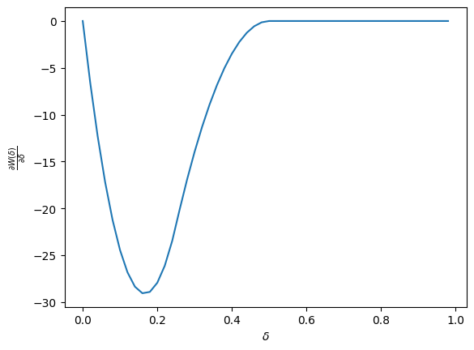

```python
def test_derivative_W_2d():
	h = 0.5
	delta = torch.arange(0, 2*h, 2*h/50).cuda()
	W = torch.empty_like(delta)

	@ti.kernel
	def kernel_test(W: ti.types.ndarray(), delta: ti.types.ndarray(), h: float):
		for i in range(delta.shape[0]):
			W[i] = cal_derivative_W_2d(delta[i], h)
	kernel_test(W, delta, h)

	plt.plot(delta.cpu().numpy(), W.cpu().numpy())
	plt.xlabel(r"$\delta$")
	plt.ylabel(r"$\frac{\partial W(\delta)}{\partial \delta}$")
	plt.show()

test_derivative_W_2d()
```

Convenient notations (and their calculating functions):

$$ W_{ij} = W(||x_i - x_j||) $$$$ \begin{aligned} \nabla_i W_{ij} &= \frac{\partial W(||x_i - x_j||)}{\partial ||x_i - x_j||} \frac{\partial ||x_i - x_j||}{\partial x_i} \\ &= \frac{\partial W(||x_i - x_j||)}{\partial ||x_i - x_j||} \frac{x_i - x_j}{||x_i - x_j||} \end{aligned} $$

When $||x_i - x_j|| = 0$, we just let $\nabla_i W_{ij} = 0$.

```python
@ti.func
def cal_W_2d_ij(xi, xj, h):
	delta = ti.math.length(xi-xj)
	return cal_W_2d(delta, h)

@ti.func
def cal_derivative_W_2d_ij(xi, xj, h):
	delta = ti.math.length(xi-xj)
	res = ti.Vector([0.0, 0.0])
	if delta != 0:
		der_W = cal_derivative_W_2d(delta, h)
		res = der_W / delta * (xi-xj)
	return res
```

Partial derivates using kernel estimation:

```python
@ti.kernel
def kernel_cal_grad_p(
	grad_p: ti.types.ndarray(),
	p: ti.types.ndarray(),
	m: ti.types.ndarray(),
	rho: ti.types.ndarray(),
	x: ti.types.ndarray(),
	h: float,
):
	for k in range(p.shape[0] * p.shape[0]):
		i = int(k / p.shape[0])
		j = k % p.shape[0]

		xi = ti.Vector([x[i, 0], x[i, 1]])
		xj = ti.Vector([x[j, 0], x[j, 1]])

		deri_W = cal_derivative_W_2d_ij(xi, xj, h)
		p_rho = (p[i]+p[j])/rho[i]
		res = m[j] * p_rho * deri_W
		grad_p[i, 0] += res[0]
		grad_p[i, 1] += res[1]

def cal_grad_p(p, m, rho, x, h):
	grad_p = torch.zeros((p.shape[0], 2))
	kernel_cal_grad_p(
		grad_p, p, m, rho, x, h
	)
	return grad_p
```

```python
def test_cal_grad_p():
	with torch.cuda.device(0):
		p = torch.ones(2)
		m = torch.ones(2)
		rho = torch.ones(2)
		x = torch.randn((2,2))
		h = 4.0
		grad_p = cal_grad_p(p, m, rho, x, h)
		print(f"x = {x.cpu().numpy()}")
		print(f"grad_p = {grad_p.cpu().numpy()}")
test_cal_grad_p()
```

```
x = [[ 0.9617971  1.9108216]
 [-0.608509  -0.674509 ]]
grad_p = [[-0.01052213 -0.01732348]
 [ 0.01052213  0.01732348]]
```

```python
@ti.kernel
def kernel_cal_rho(
	rho: ti.types.ndarray(),
	m: ti.types.ndarray(),
	x: ti.types.ndarray(),
	h: float,
):
	for k in range(rho.shape[0] * rho.shape[0]):
		i = int(k / rho.shape[0])
		j = k % rho.shape[0]

		xi = ti.Vector([x[i, 0], x[i, 1]])
		xj = ti.Vector([x[j, 0], x[j, 1]])

		W = cal_W_2d_ij(xi, xj, h)
		rho[i] += m[j] * W


def cal_rho(m, x, h):
	rho = torch.zeros((x.shape[0]))
	kernel_cal_rho(rho, m, x, h)
	return rho
```

```python
def test_cal_rho():
	m = torch.ones(2)
	x = torch.randn((2,2))
	h = 4.0
	rho = cal_rho(m, x, h)
	print(rho)
test_cal_rho()
```

```
tensor([0.1949, 0.1949])
```

## Boundary conditions

Below the superscript $^t$ will be ignored sometime for convenience.

#### Intial conditions

All we need are $x^0, v^0, \rho^0$.

$\rho^0$ is a constant: $\rho^0_i = \bar{\rho^0}$.

```python
def cal_rho_0(n, bar_rho_0):
	return torch.empty(n).fill_(bar_rho_0)
```

And $x^0, v^0$ are:

$$ x \sim U[x_{left}, x_{right}] \times U[x_{down}, x_{up}] \\ v \sim \mathcal{N}(0, v_{hor}^2) \times \mathcal{N}(0, v_{ver}^2) $$

Sample $n$ times, then we get $x_1, x_2, \dots, x_n$ and $v_1, v_2, \dots, v_n$.

```python
def cal_x_0(n, x_left, x_right, x_down, x_up):
	x = torch.empty(size=(n, 2))
	x[:, 0].uniform_(x_left, x_right)
	x[:, 1].uniform_(x_down, x_up)
	return x
```

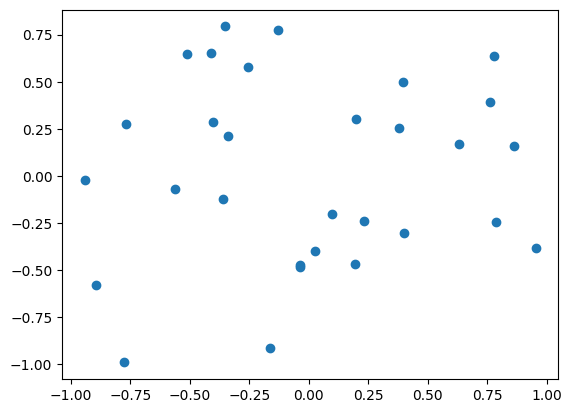

```python
def test_x_0():
	x = cal_x_0(30, -1, 1, -1, 1)
	plt.scatter(x[:, 0], x[:, 1])
	plt.show()
test_x_0()
```

```python
def cal_v_0(n, dt, x_left, x_right, x_down, x_up):
	v = torch.empty(size=(n, 2))
	v_hor = (x_right - x_left) / dt / 10
	v[:, 0].normal_(0, v_hor)
	v_ver = (x_up - x_down) / dt / 10
	v[:, 1].normal_(0, v_ver)
	return v
```

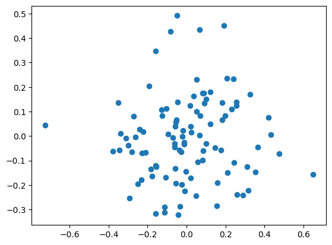

```python
def test_v_0():
	v = cal_v_0(100, 1.0, -1, 1, -1, 1)
	plt.scatter(v[:, 0], v[:, 1])
	plt.show()
test_v_0()
```

#### Boundary handle

Define $x = (x^\chi, x^\gamma), v_i = (v^\chi, v^\gamma)$.

The liquid is only allowed to be in a small rect container in all time:

$$ x^\chi \in [x_{left}, x_{right}] \\ x^\gamma \in [x_{down}, x_{up}] \\ $$

We just explicitly adjust $x, v$ to meet the requirements above:

$$ \begin{aligned} &\text{If } x^\chi < x_{left}: & x^\chi \leftarrow x_{left}, & \quad v^\chi \leftarrow \eta |v^\chi| \\ &\text{If } x^\chi > x_{right}: & x^\chi \leftarrow x_{right}, & \quad v^\chi \leftarrow - \eta |v^\chi| \\ &\text{If } x^\gamma < x_{down}: & x^\gamma \leftarrow x_{down}, & \quad v^\gamma \leftarrow \eta |v^\gamma| \\ &\text{If } x^\gamma > x_{up}: & x^\gamma \leftarrow x_{up}, & \quad v^\gamma \leftarrow - \eta |v^\gamma| \end{aligned} $$

where $\eta \in [0, 1]$ is a constant.

```python
@ti.kernel
def kernel_boundary_handle(
	x: ti.types.ndarray(),
	v: ti.types.ndarray(),
	x_left: float, x_right: float,
	x_down: float, x_up: float,
	eta: float,
):
	for i in range(x.shape[0]):
		if x[i, 0] < x_left:
			x[i, 0] = x_left + (x_right - x_left) * 0.01 * ti.random(float)
			v[i, 0] = eta * abs(v[i, 0])
		if x[i, 0] > x_right:
			x[i, 0] = x_right - (x_right - x_left) * 0.01 * ti.random(float)
			v[i, 0] = - eta * abs(v[i, 0])
		if x[i, 1] < x_down:
			x[i, 1] = x_down + (x_up - x_down) * 0.01 * ti.random(float)
			v[i, 1] = eta * abs(v[i, 1])
		if x[i, 1] > x_up:
			x[i, 1] = x_up - (x_up - x_down) * 0.01 * ti.random(float)
			v[i, 1] = - eta * abs(v[i, 1])

def boundary_handle(x, v, x_left, x_right, x_down, x_up, eta):
	x_ = x.clone()
	v_ = v.clone()
	kernel_boundary_handle(x_, v_, x_left, x_right, x_down, x_up, eta)
	return x_, v_
```

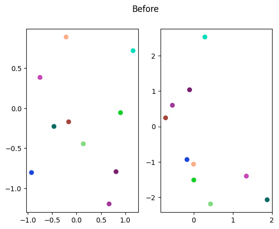

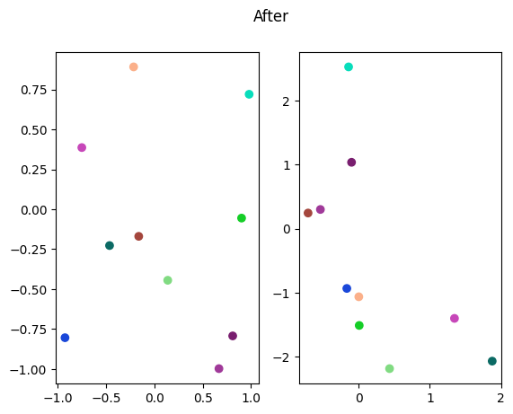

```python
def test_boundary_handle():
	n = 10
	x = torch.empty((n, 2)).uniform_(-1.2, 1.2)
	v = torch.empty((n, 2)).normal_(0, 1.0)
	eta = 0.5

	colors = torch.rand((n, 3)).numpy()

	def PLOT(title):
		plt.subplot(121)
		plt.scatter(x[:, 0], x[:, 1], c=colors)
		plt.subplot(122)
		plt.scatter(v[:, 0], v[:, 1], c=colors)
		plt.suptitle(title)
		plt.show()

	PLOT("Before")
	x, v = boundary_handle(x, v, -1, 1, -1, 1, eta)
	PLOT("After")
test_boundary_handle()
```

#### External conditions

Mass $m$ and external acceleration $b$ are external conditions.

We just make them constant:

$$ m_i^t = \bar{m} \\ b_i^t = \bar{b} = (0, -g) \\ $$

where $g$ is gravity acceleration.

```python
def cal_m(n, bar_m):
	return torch.empty((n)).fill_(bar_m)
def cal_b(n, g):
	b = torch.empty((n, 2))
	b[:, 0].zero_()
	b[:, 1].fill_(-g)
	return b
```

## Solve

```python
torch.manual_seed(54891564)
```

```
<torch._C.Generator at 0x2039c1d5010>
```

#### Constants

```python
frame_num = 600
n = 500
h = 0.03
fps = 60
dt = 1.0/fps
bar_rho_0 = 1.0
bar_m = 1.0
g = 9.8
kappa = 0.5

eta = 0.5
x_left = -1
x_right = 1
x_down = -1
x_up = 1
```

#### Init

```python
m = cal_m(n, bar_m)
b = cal_b(n, g)
rho_0 = cal_rho_0(n, bar_rho_0)
```

```python
x0 = cal_x_0(n, x_left, x_right, x_down, x_up)
v0 = cal_v_0(n, dt, x_left, x_right, x_down, x_up)
colors = torch.rand((n, 3))
```

```python
x = x0.clone()
v = v0.clone()
```

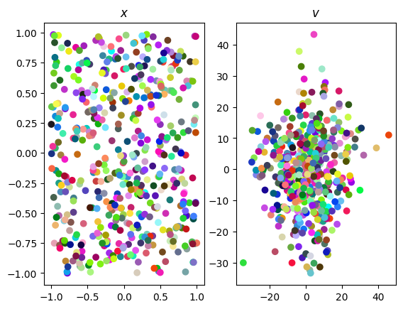

```python
def PLOT():
	plt.subplot(121)
	plt.title("$x$")
	plt.scatter(x[:, 0], x[:, 1], c=colors)
	plt.subplot(122)
	plt.title("$v$")
	plt.scatter(v[:, 0], v[:, 1], c=colors)
	plt.show()
PLOT()
```

#### Tick

```python
rho = torch.empty((n))
p = torch.empty((n))
grad_p = torch.empty((n, 2))
a = torch.empty((n, 2))
def tick():
	global x, v, rho, p, grad_p, a
	rho = cal_rho(m, x, h)
	p = cal_p(kappa, rho, rho_0)
	grad_p = cal_grad_p(p, m, rho, x, h)
	a = cal_a(b, grad_p, rho)
	v = v_explicit_euler(v, dt, a)
	x = x_implicit_euler(x, dt, v)
	x, v = boundary_handle(x, v, x_left, x_right, x_down, x_up, eta)
```

```python
class Timeline:
	def __init__(self):
		self.key2dict: dict[str, dict[int, torch.Tensor]] = {}
		self.key2tensor: dict[str, torch.Tensor] = {}

	def memo(self, i, key2target: dict[str, torch.Tensor]):
		for key, target in key2target.items():
			if not key in self.key2dict.keys():
				self.key2dict[key] = {}
			self.key2dict[key][i] = target.clone()

	def tensoralize(self):
		for key, dic in self.key2dict.items():
			n = max(dic.keys())
			tensor = torch.empty(
				size=(n+1, *dic[n].shape),
				device=dic[n].device,
				dtype=dic[n].dtype
			)
			for i, v in dic.items():
				tensor[i] = v
			self.key2tensor[key] = tensor

	def __getitem__(self, key):
		return self.key2tensor[key]
```

```python
timeline = Timeline()
for i in range(frame_num):
	tick()
	timeline.memo(i, {
		"x": x,
		"v": v,
		"rho": rho,
		"p": p,
		"grad_p": grad_p,
		"a": a,
	})
timeline.tensoralize()
```

## Render

```python
from torch.nn import Module

class PointRender2D(Module):
	def __init__(self) -> None:
		super().__init__()

	def forward(self,
		centers: torch.Tensor,
		radius: float,
		viewport: list[float],
		height: int, width: int,
	) -> Image:
		from PIL import Image, ImageDraw
		vx, vy, vw, vh = viewport
		r = radius

		if centers is torch.Tensor:
			centers = centers.numpy()

		canvas = Image.new(mode="RGBA", size=(width, height), color=(255, 255, 255, 255))
		draw = ImageDraw.Draw(canvas)
		for x, y in centers:
			x = (x-vx)/vw*width
			y = height - (y-vy)/vh*height
			draw.ellipse((x-r, y-r, x+r, y+r), fill=(255, 0, 0, 255))
		return canvas

def imgs2gif(imgs, output_dir, filename, framerate):
	import os
	filepath = os.path.join(output_dir, filename)
	os.makedirs(output_dir, exist_ok=True)
	with open(filepath, mode="bw") as fp:
		imgs[0].save(fp, format="gif", save_all=True, append_images=imgs[1:], optimize=False, duration=1000/framerate, loop=0)
	return filepath
```

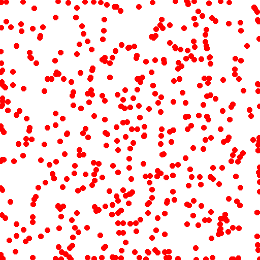

```python
from tqdm import tqdm
render = PointRender2D()

render_fps = 24
render_step = math.ceil(fps / render_fps)

imgs = []
for i in tqdm(range(0, len(timeline["x"]), render_step)):
	x = timeline["x"][i]
	imgs.append(render(
		centers = x,
		radius = 5.0,
		viewport = [x_left, x_down, x_right-x_left, x_up-x_down],
		height = 512, width = 512,
	))

img_path = imgs2gif(
	imgs=imgs,
	output_dir="./outputs/",
	filename="res.gif",
	framerate=fps,
)

from IPython.display import Image
Image(open(img_path, "rb").read())
```

## Analyze

```python
test_i = 10
test_frame_begin = 0
test_frame_end = frame_num
```

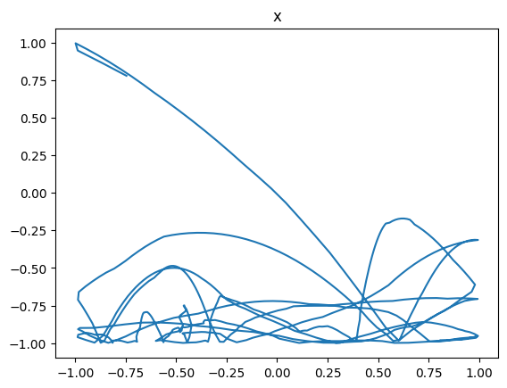

```python
test_x = timeline["x"][test_frame_begin:test_frame_end, test_i]
plt.plot(test_x[:, 0], test_x[:, 1])
plt.title("x")
plt.show()
```

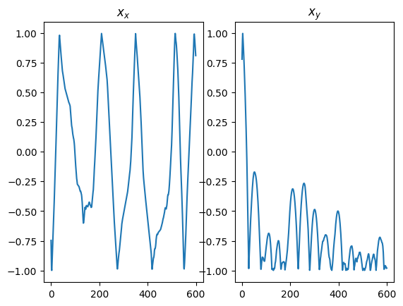

```python
test_x = timeline["x"][test_frame_begin:test_frame_end, test_i]
plt.subplot(121)
plt.plot(test_x[:, 0])
plt.title("$x_x$")
plt.subplot(122)
plt.plot(test_x[:, 1])
plt.title("$x_y$")
plt.show()
```

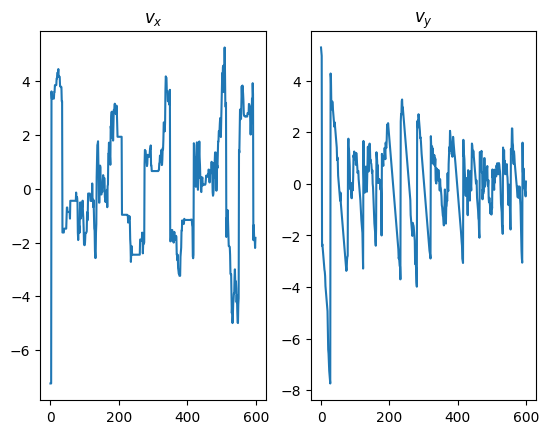

```python
test_v = timeline["v"][test_frame_begin:test_frame_end, test_i]
plt.subplot(121)
plt.plot(test_v[:, 0])
plt.title("$v_x$")
plt.subplot(122)
plt.plot(test_v[:, 1])
plt.title("$v_y$")
plt.show()
```

```python
print(test_v[200])
print(test_x[200])
```

```
tensor([1.9347, 1.7003])
tensor([ 0.7126, -0.4463])
```

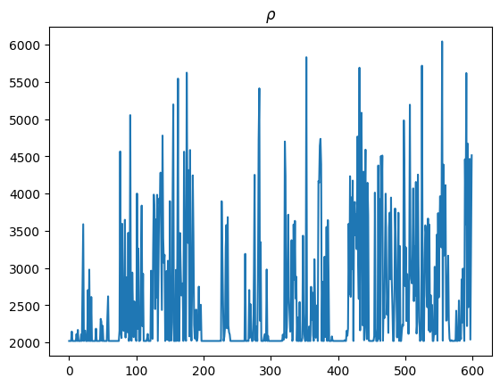

```python
test_rho = timeline["rho"][test_frame_begin:test_frame_end, test_i]
plt.plot(test_rho)
plt.title(r"$\rho$")
plt.show()
```

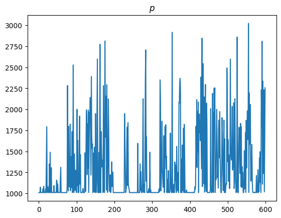

```python
test_p = timeline["p"][test_frame_begin:test_frame_end, test_i]
plt.plot(test_p)
plt.title(r"$p$")
plt.show()
```

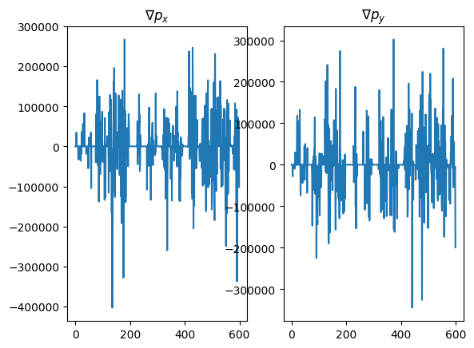

```python
test_grad_p = timeline["grad_p"][test_frame_begin:test_frame_end, test_i]
plt.subplot(121)
plt.plot(test_grad_p[:, 0])
plt.title(r"$\nabla p_x$")
plt.subplot(122)
plt.plot(test_grad_p[:, 1])
plt.title(r"$\nabla p_y$")
plt.show()
```

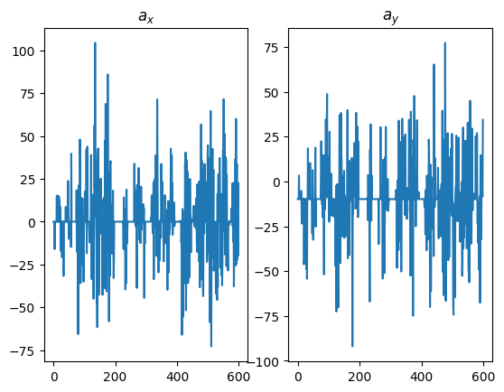

```python
test_a = timeline["a"][test_frame_begin:test_frame_end, test_i]
plt.subplot(121)
plt.plot(test_a[:, 0])
plt.title(r"$a_x$")
plt.subplot(122)
plt.plot(test_a[:, 1])
plt.title(r"$a_y$")
plt.show()
```

```python
def check_nan(key):
	print(f"Check if {key} is nan: {torch.any(torch.isnan(timeline[key])).cpu().numpy()}")
check_nan("x")
check_nan("v")
check_nan("rho")
check_nan("p")
check_nan("grad_p")
check_nan("a")
```

```
Check if x is nan: False
Check if v is nan: False
Check if rho is nan: False
Check if p is nan: False
Check if grad_p is nan: False
Check if a is nan: False
```